# Homework 6

Solution

2 April 2017

# Introduction

In this report, we examine under what circumstances, and to what extent, non-violent movements can achieve large-scale political change in the face of opposition from an existing state. We are especially charged with learning when non-violent movements are more likely to succeed than violent ones, and how large these differences in the probability of success are under different circumstances.

Three factors of particular concern are the role of state violence, the role of interventions from other states, and the role of democracy. Critics of non-violence as a political tactic have long charged that it is only effective when dealing with “nice” governments — ones which will not meet moral force with lethal violence, and which are democratic enough to be swayed by public opinion.[^1] The effectiveness of foreign interventions, either on behalf of existing governments or of opposition movements, is meanwhile a continual source of debate within countries considering such interventions, and of course for those on their receiving end.

This report thus examines how well the success of anti-government movements can be predicted on the basis of their non-violence, whether the government engages in violent repression of the movement, the level of democracy of the government, and the presence or absence of foreign aid to the two sides in the conflict. We also consider a number of control variables: the duration of the movement, the year in which it peaked, whether the government was the target of international sanctions, and whether or not significant elements of the government’s security forces defected to the movement. Sanctions and defections have obvious relevance to success; the ability of the movement to sustain itself for a long time may also be relevant; and year can serve as a proxy for political conditions extending beyond the borders of any one country, but perhaps affecting how well governments can resist internal pressures, or how willing opposition groups are to challenge state power.

## Preliminary Examination of the Data

The units of analysis in our data set are particular political movements in particular countries. The data file contains 323 such movements, in 136 countries — this indicates that some countries have seen multiple movements, but, on examination, many countries have only one recorded movement.

The summary statistics of the variables reveal that there is little missing data (2 for `defect` and 54 for `democracy`). 32.8% of the movements were non-violent. The oldest movement is from from 1902, the latest from 2006, with most in the last half of the period (Figure 1), and one quarter of them all since 1993.

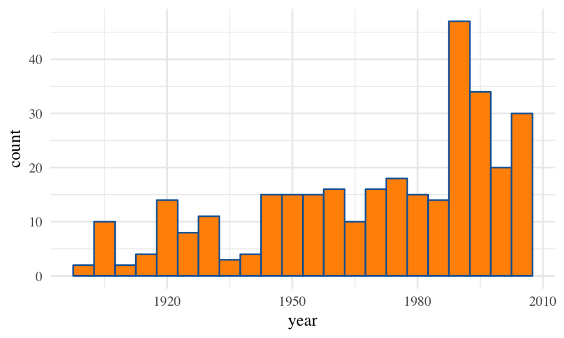

Figure 1: Histogram of peak years

(This may be a bias in the sample, or it may mean such movements are becoming more frequent, and our analysis is more important than ever.) Otherwise, the only variable whose distribution turned out to be relevant to the analysis was `duration`, which is highly skewed to the right:

```
##    Min. 1st Qu.  Median    Mean 3rd Qu.    Max.
##       2     360     730    1928    2190   21170
```

Since it was part of our terms of reference to use logistic-additive models, we need to re-code partial successes as either full successes or complete failures. Since it’s rare for any political force to ever be *completely* successful, we will re-code partial successes as successes. 51.4% of the movements then count as successful.

# The Model

## Formulation

To address the scientific questions, we turn to a generalized additive model, which relates the probability of movement success to the factors of interest. Specifically, following our terms of reference, we use a **logistic** model, meaning that our model will directly predict the log odds of success, $\log{p/(1-p)}$, and the probability of success only after a transformation. Moreover, again following the terms of reference, we use an **additive** model — each term in the model makes a separate, additive contribution to the log odds (i.e., it multiplies the odds of success). Mathematically, writing $x_j$ for the different predictor variables, we start with a model of the form
$$\log{\frac{p}{1-p}} = \alpha + \sum_{j}{f_j(x_j)}$$
where the $f_j$ are smooth, possibly linear, functions of the predictors. (If $x_j$ is binary, $f_j$ is always linear!) We may also include terms in the sum which are functions of pairs of variables, to capture interactive effects or contrasts between conditions.

Our initial formulation of which terms to put in the model is guided by the terms of reference, and the analytical questions posed to us. We are told that all three continuous predictors — the year, the duration, and the level of democracy — should be included. We also include all of the categorical predictors. The analytical questions specifically ask about the interaction of non-violence (on the part of the movement) with violent repression (on the part of the government), so we include that interaction term. The last of the analytical questions also ask about the interactions between non-violence and democracy. We therefore include both a direct effect for democracy, and a partial response function interacting democracy with non-violence. Categorical predictors may not be smoothed, so they enter into the model as parametric terms; all the continuous variables will be smoothed, because we have no theoretical reason to favor any parametric form for them.

The specification we are led to, then, may be put in R form:

```r
mdl.base <- gam(target ~ nonviol*viol.repress + sanctions + aid + support
                + defect + s(year) + s(duration)
                + s(democracy) + s(democracy,by=nonviol),
                data=navc, family="binomial", na.action=na.exclude)
```

The `nonviol*viol.repress` expression in the formula will give terms for the non-violence of the movement, for the presence of violent repression, and for a non-violent movement confronting violent repression; it is that last which tries to captures the difference in response to repression between non-violent and violent movements. Similarly, this model includes a direct effect of democracy, applying to all movements, and an additional smooth function of democracy that *only* gets added for non-violent movements. The last function allows the contrast between violent and non-violent movements to change with the level of democracy.

However, `duration` was extremely skewed; this can cause problems for smoothing when there are not that many observations. We thus also consider a model which is the same as the previous one but smoothes `log10(duration)` instead of `duration`. Using log base 10 rather than natural log helps us keep things interpretable (as most people grasp ${10}^3$ better than $e^{6.9}$). To decide which version is better, we use cross-validation, and in particular the cross-validated deviance score which is computed by the `gam` function as part of its model-fitting. The cross-validated deviance without logging `duration` is 0.133, while that of the model with transformation is 0.127. Since taking the log of `duration` before smoothing it not only unskews, it leads to better predictions, we discard the first model in favor of the logged one.

## Analysis, Including Estimates and Uncertainties

Table 1 gives the model’s parametric terms. Here, and throughout, all confidence bands were calculated by resampling of cases.

Table 1: Point estimates and 95% confidence intervals for the model’s parametric terms based on the bootstrap replications.

|  | lo | est | hi |
| --- | --- | --- | --- |
| (Intercept) | -3.84 | -0.36 | 2.38 |
| nonviol | -609.23 | 3.12 | 206.19 |
| viol.repress | -2.78 | -0.65 | 1.17 |
| sanctions | -1.78 | -0.05 | 2.01 |
| aid | -1.30 | 0.10 | 1.78 |
| support | -0.85 | 0.72 | 2.06 |
| defect | -0.22 | 0.91 | 2.51 |
| nonviol:viol.repress | -3.43 | -0.57 | 387.51 |

The coefficient on `nonviol` is positive, meaning that non-violent movements are more likely to be successful than violent ones are; indeed, the positive coefficient of 3.1 means that a non-violent movement’s odds of success are 23 times those of an otherwise-similar but violent movement. Violent repression on the other hand lowers the odds of success. The fact that the interaction term `nonviol:viol.repress` is negative means that violent repression hurts non-violent movements more than violent ones — though a non-violent movement confronting violence still has odds 13 times better than those of a violent movement in the same situation.

The coefficient on `aid` implies that when the government receives aid from other states specifically to help it deal with the movement, the movement’s odds of success go *up* by about 10%. This does not necessarily mean that such aid is counter-productive; other countries may only send aid to governments which are already in trouble, dealing with movements which would have been even more likely to win otherwise; the coefficient would combine the real effects of aid with this “selection effect”[^2]. The coefficient on support from foreign governments to the anti-government movement is also positive[^3], indicating an increase in the odds by a factor of 2. The coefficient on sanctions is negative[^4], indicating that sanctions on the government predict a *lower* probability of success for the movement. Finally, and unsurprisingly[^5], defection of the security forces increases the movement’s chances.

All of the above refers to the point estimates. The other two columns of Table 1 show the 95% confidence limits, which in every single case include 0; some of them (like the coefficients on nonviolence) are remarkably wide. This does not appear to be a bug, but rather a genuine reflection of massive instability in all the coefficients, even while the model as a whole manages to predict quite well.

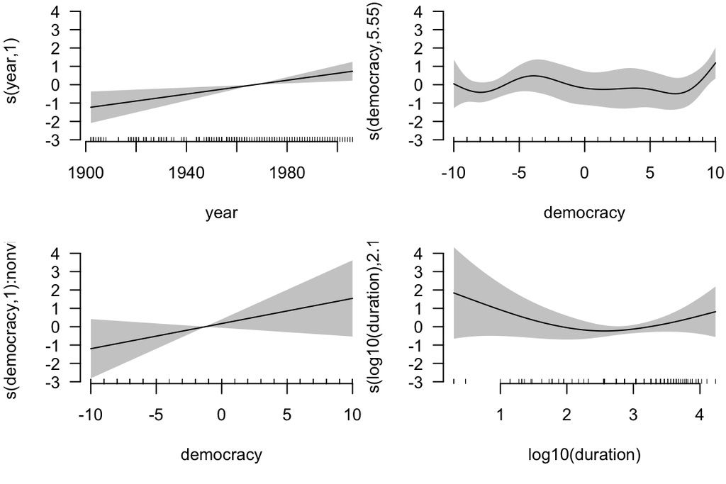

Figure 2 shows the partitial response functions for our model. The partial response to year increases monotonically over time, tracking the break-up of empires from global military conflicts[^6]. The partial response to duration says that very short and very enduring movements are both more likely to succeed than those which last about a year. The high success rate of short movements may be another selection effect — a movement can win quickly, but, once it’s mobilized, losing takes times.

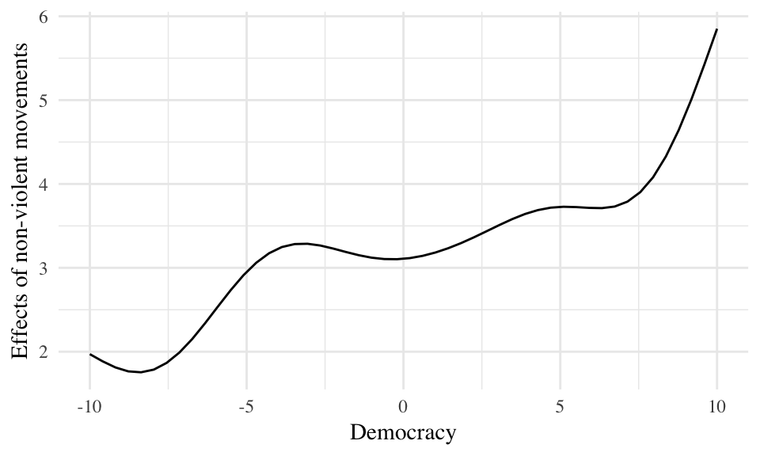

Figure 3: The sum of the two democracy curves

Finally, we consider democracy and its interaction with non-violence. Figure 2 shows the two relevant partial response functions: the main effect of democracy, applying to all movements, and the interaction of democracy and non-violence. The former shows a somewhat complicated pattern — movements are relatively more likely to succeed against the most anti-democratic regimes (hereditary monarchies), and then again even more against those which are only moderately anti-democratic ($\approx -4$: South Korea a few decades ago, Latin American military dictatorships etc.). The odds of success then fall as the country becomes more democratic, only to shoot up in the most democratic countries. The interaction curve, added on for non-violent movements only, is a straight line through the origin, saying that the extra contribution of non-violence is increasingly positive as the country becomes more democratic, and increasingly negative as an anti-democratic country becomes even less democratic. To get the over-all pattern of success for non-violent movements as a function of democracy, we add the two curves (Figure 3); this sum shows that over-all non-violent movements are increasingly likely to succeed as the country becomes more democratic, but without much difference over a broad range of values in the middle.

## Model Checking

### Calibration

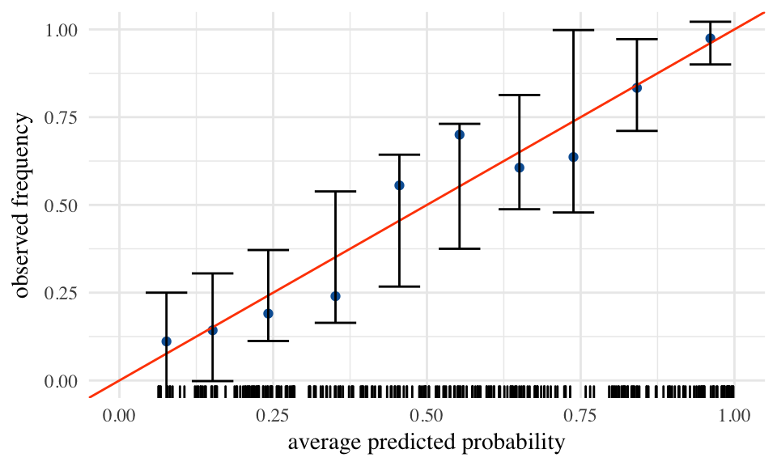

Figure 4: Calibration of probabilities

Figure 4 checks whether the model’s probabilities are calibrated, using probability bins 10 percentage points wide. Not only does success get more common as the predicted probability rises, those probabilities are reasonably well-calibrated, with deviations easily explicable by chance.

### Residuals

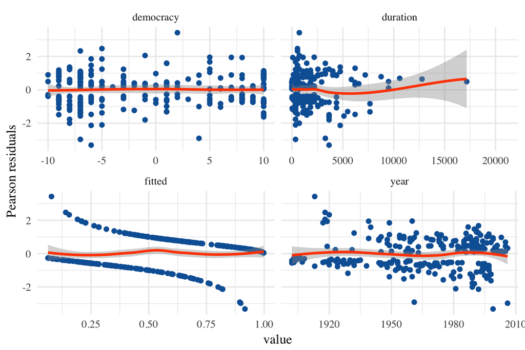

Figure 5: Pearson residuals